# Decision Trees - Theory

```python
from IPython.display import Image
```

## Decision Trees - Introduction

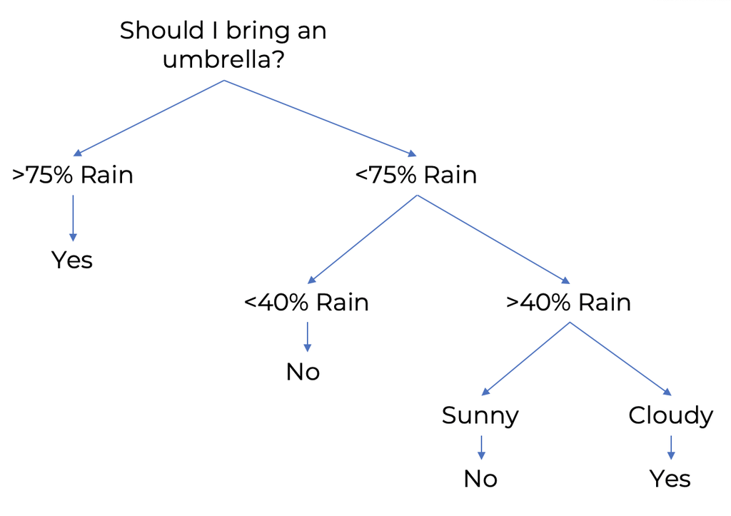

```python
Image("img/decision_tree.png")
```

A decision tree is built from a series of binary questions where each "leaf" or node corresponds to an answer.

- At each leaf, we predict the response based on the training data that belong to the leaf
- A terminal node is an ending node

## Decision Trees for Classification

Classification trees have class probabilities at each leaf.

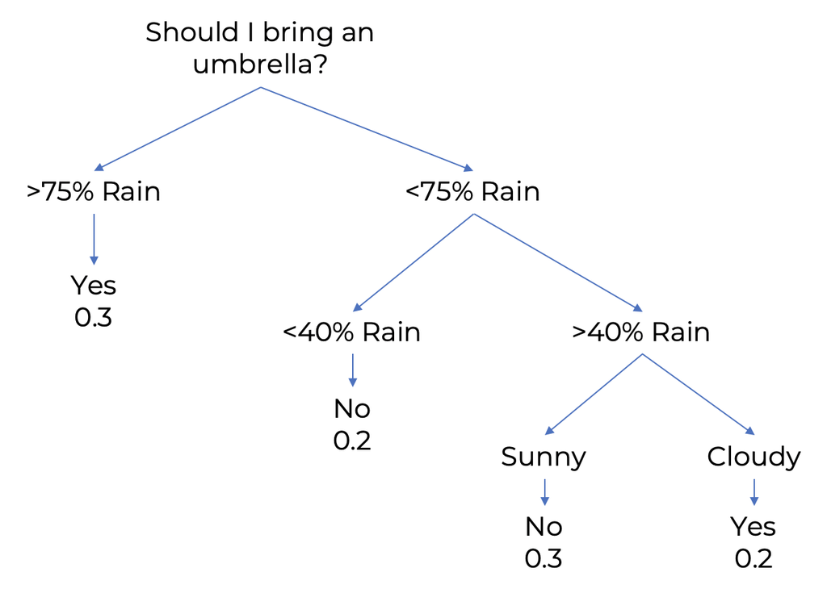

```python
Image("img/decision_tree_with_probs.png")
```

The success of a decision tree model for classification depends on how the underlying data looks, as illustrated below:

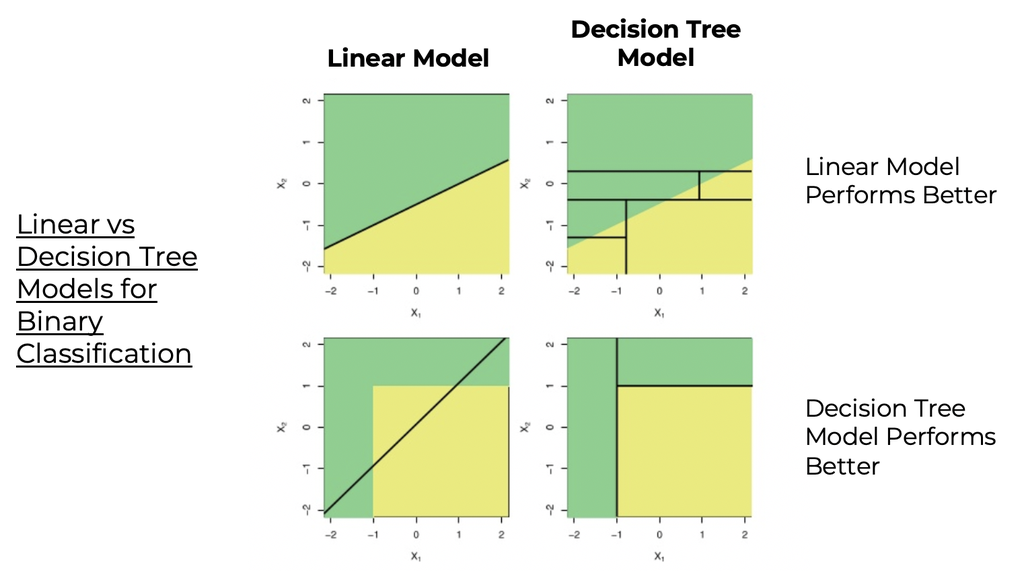

```python
Image("img/linear_vs_decision_tree.png")
```

Source of graphs: Introduction to Statistic Learning, Ch 8 Tree Methods

### Classification Performance

Just as we did for logistic regression, we use deviance as our performance metric, where a smaller deviance is better.

- $D=-\sum_{i=1}^{n}\sum_{l=1}^{K}I(y_i=l)log(\hat{p}(y_i=l|x_i))$

Breaking this down:

- There are $n$ terminal nodes and $K$ classes
- $I(y_i=l)$ -- this represents the number of observations in the $i$th terminal node that belongs to class $l$
- $\hat{p}(y_i=l|x_i)$ -- this represents the probability that $y_i$ is class $l$ given the set of features $x_i$ at the $i$th terminal node

Looking at the decision tree models above (in the linear vs. decision tree model comparison), we construct classification trees by creating boxes $R_1, R_2, ... R_j$ that minimize deviance. In the context of these boxes, we can rewrite deviance as:

- $D=-\sum_{j=1}^J\sum_{l=1}^{K}|R_j|\hat{p}_{jl}log(\hat{p}_jl)$

Again, we are aiming to minimize these deviances at every box $R_1, R_2,...R_j$.

We cannot construct decision trees based off of what reduces classification error ($1-max_l\hat{p}_{jl}$).

- Consider an example where we can only split the data into left/right errors of 0% and 50% or 25% and 25%
- In either case, the cumulative classification error is 50%
- Consequenty, if we construct based off of classification error then we must make an arbitrary, indifferent decision

However, we want extreme splits (as seen in the linear vs. decision tree model comparison).

- Deviance prefers more extreme splitting, so it will pick the split of 0% and 50% over 25% and 25%
- Yes, one side will have a 50% classification error, but one class will be clearly partitioned off

## Decision Trees for Regression

Regression trees provide a mean response at each leaf.

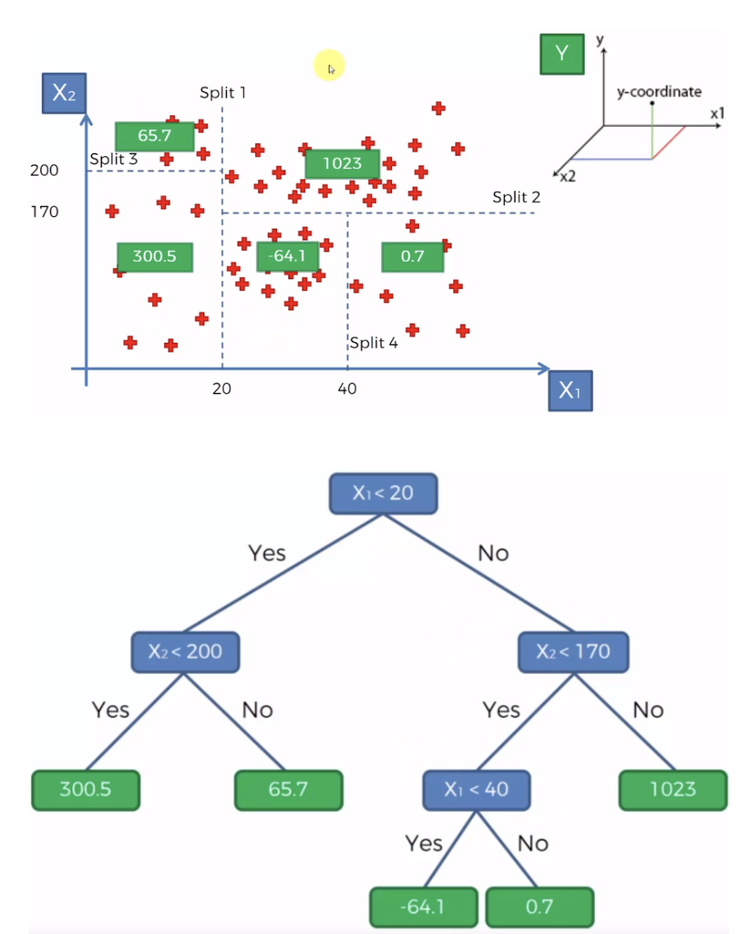

```python
Image("img/decision_tree_regression.png")
```

Source: "Decision Tree Regression in 6 Steps with Python" by Samet Girgin

In the above image, each number in a green box represents the mean response of the data points in its respective split or box.

### Regression Performance

Just as in linear regression, we aim to minimize $RSS$, $MSE$, or $RMSE$.

- $RSS=\sum_{i=1}^{n}(y_i-\hat{y}_i)^2$, for $n$ terminal nodes

To build a regression tree, we look for boxes $R_1, R_2,...,R_j$ that minimize $RSS$, given by:

- $\sum_{j=1}^{J}\sum_{i\in{R_j}}(y_i-\hat{y}_{R_j})^2$

where $\hat{y}_{R_j}$ represents the mean response for the training data in box $R_j$.

## CART Algorithm

CART stands for Classification and Regression Tree (I know, very blunt), and is an algorithm for creating decision trees. This can also be called recursive binary splitting.

It is computationally infeasible to consider every possible split into $J$ boxes, so we apply the CART algorithm

- The CART algorithm is a greedy algorithm.
- A greedy algorithm is any algorithm that follows the problem-solving heuristic of selecting the locally optimal choice at each stage rather than finding the global optimum
  - E.x. "To maximize my GPA in the long-run, each semester I will take classes with the best grading curves."
- A heuristic is a way of creating an estimate that is computationally efficient and can give a good, though not necessarily optimal, response (in some cases a greedy algorithm is also the optimal algorithm)

To break down the CART algorithm:

- Split the data into two different decisions using $X_j$ < $\gamma$, where the split $\gamma$ minimizes the $RSS$ or deviance at that stage
- Take each new partition and split again, based on where the split $\gamma$ minimizes the $RSS$ or deviance at that stage
  - Each new child node contains a subset of data
  - Each subset has its own prediction values
  - In this way, we can view the $\gamma$ splits as finding locally optimal points for minimizing $RSS$ and deviance rather than a global one
- Stop splitting when the amount of data in each node is too small or the improvements in $RSS$ or deviance are negligible

### Pruning

Remember the bias-variance tradeoff! The more nodes we have in a decision tree, the more likely we will overfit.

How can we apply a penalty for using more nodes ? We choose a cost complexity $\alpha$ and find a tree that minimizes:

- $\sum_{m=1}^{|T|}\sum_{i:x_i\in{R_m}}(y_i-\hat{y}_{R_m})^2+\alpha|T|$

As $\alpha$ increases, the tree gets smaller, thus "pruning" branches.

Use cross validation to select $\alpha$!

[figure not shown]

```python
Image("img/prune_example.jpeg")
```

Source: Medium

## Random Forest

In a random forest, we make many trees, where each tree has a random set of data and features. To make a prediction:

- In regression, we average the output of all the trees
- In classification, we take the majority (what class has the most "leaves"?)

We can reduce variance by using randomized trees.

The training dataset in each random tree is **bootstrapped.**

- Suppose we have a dataset with $n$ data points
- A bootstrapped dataset is one where we randomly sample data points from this dataset with replacement -- in the case of a random forest, we sample $n$ data points
- In other words, we are resampling from a single dataset to create many simulated datasets
- This is very useful method to calculate standard errors, make confidence intervals, and perform hypothesis tests for sample statistics

### Bootstrap Visualization

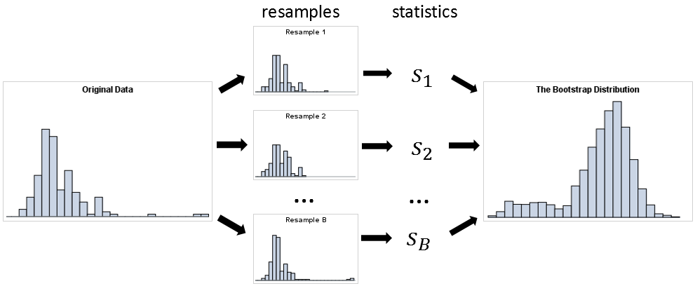

```python
Image("img/bootstrapSummary.png")
```

Source: SAS blog

To decide what variable to split on, we select $m$ out of $p$ features, chosen at random. If $m$ = $p$ then this is called bagging.

- For classification, default is $m=\sqrt{p}$ and the min. node size is 1
- For regression, default is $m=\frac{p}{3}$ and the min. node size is 5
- In practice, cross-validate $m$

Because bootstrapping allows us to simulate multiple datasets from the same distribution, we can compute Out-of-Bag (OOB) error by using one tree's data and features to predict $\hat{y}_i$ on other trees.

More trees generally lead to better performance, though after 100 trees the improvement in performance is almost always negligible or non-existent (the improvement flattens out).

### Random Forest for Classification

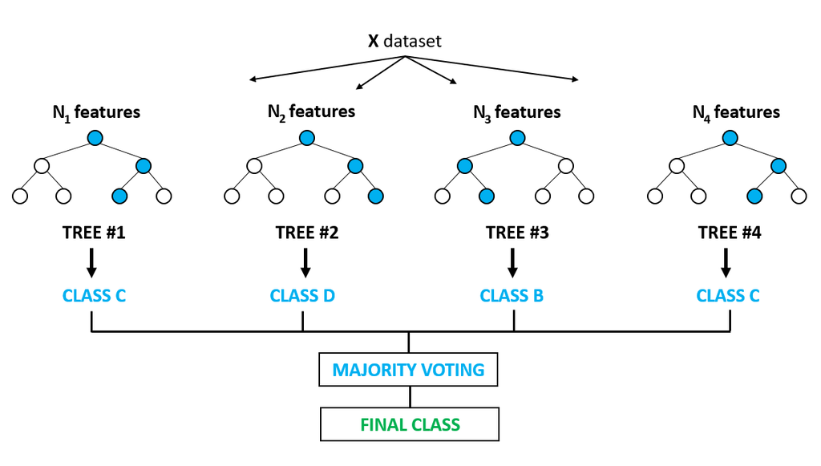

```python
Image("img/random_forest_classification.png")
```

Source: Abilash R, Medium

In the above, the final class would be **class C** because there are 2 instances of C, but only 1 instance of D and B.

### Random Forest for Regression

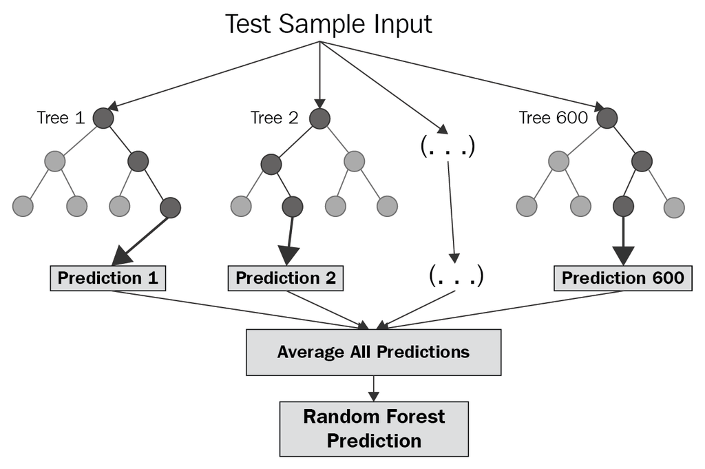

```python
Image("img/random_forest_regression.png")
```

Source: Towards Data Science

Here, we average the predicted values rather than take a majority vote.

### Feature Importance

Because the random forest randomizes the datasets and feature sets used in each tree, we can actually get an understanding of what features were most useful as predictors based on what features are most commonly/significantly utilized across trees.

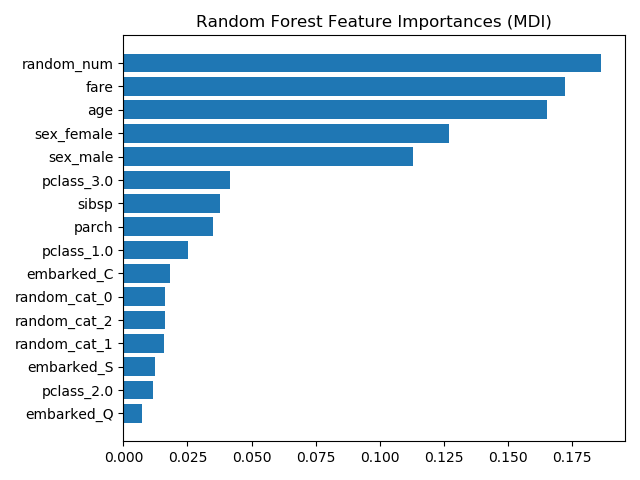

```python
Image('img/feature_importance.png')
```

Source: sci-kit learn documentation

From the above, we see that random_num, fare, and age are the three most important features. Embarked_Q is the least important feature.

## More Resources

[Towards Data Science: "Understanding Random Forest"](https://towardsdatascience.com/understanding-random-forest-58381e0602d2)

[UC Berkeley - Random Forest Explanation](https://www.stat.berkeley.edu/~breiman/RandomForests/cc_home.htm)

[Harvard Business Review Case on Decision Trees](https://hbr.org/1964/07/decision-trees-for-decision-making)